# GAMLSS, regresión de cuantiles y regresión logística - Clase 6

Cecilia Oliva

04/07/2023

# GAMLSS y regresión de cuantiles

## Ejemplo

Una compañía encargada del suministro de energía eléctrica estudia la evolución del consumo eléctrico de todas las casas de una ciudad en función de la hora del día. La empresa debe de ser capaz de provisionar, en un momento dado, con hasta un 50% de electricidad extra respecto al promedio. Esto significa un máximo de 15 MWh. Estar preparado para suministrar este extra de energía implica gastos de personal y maquinaría, por lo que la compañía se pregunta si es necesario estar preparada para producir tal cantidad durante todo el día, o si, por lo contrario, podría evitarse durante algunas horas, ahorrando así gastos.

```r
library(tidyverse)
set.seed(12345)
n <- 2000
x <- runif(min = 0, max = 24, n = n) %>% sort() #Simulación distribución uniforme en el rango x
y <- rnorm( n, mean = 10, sd = 1 + 1.5*(4.8 < x & x < 7.2) + 4*(7.2 < x & x < 12) + 1.5*(12 < x & x < 14.4) + 2*(x > 16.8) )  #Simulación de distribución normal para y
```

Calculamos los cuantiles 0,1 y 0,9, y luego graficamos la distribución de y, es decir de la variable respuesta consumo.

```r
cuantil_10 <- qnorm( p = 0.1, mean = 10, sd = 1 + 1.5*(4.8 < x & x < 7.2) + 4*(7.2 < x & x < 12) + 1.5*(12 < x & x < 14.4) + 2*(x > 16.8) )
cuantil_90 <- qnorm( p = 0.9, mean = 10, sd = 1 + 1.5*(4.8 < x & x < 7.2) + 4*(7.2 < x & x < 12) + 1.5*(12 < x & x < 14.4) + 2*(x > 16.8) )
datos <- data.frame(consumo = y, hora = x, cuantil_10, cuantil_90)
# No puede haber consumos negativos
datos <- datos %>% filter(consumo >= 0)
datos <- datos %>% mutate(dentro_intervalo = ifelse( consumo > cuantil_10 & consumo < cuantil_90, TRUE, FALSE ) )

mean(datos$consumo)
```

```
## [1] 10.02138
```

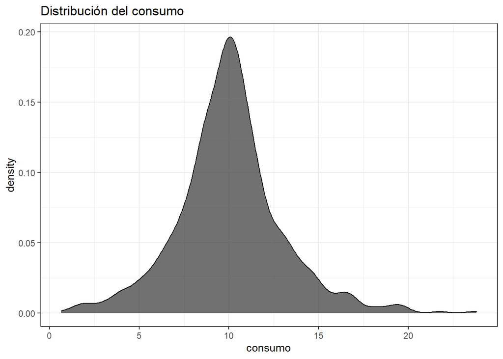

```r
pp <- ggplot(data = datos, aes(x = consumo)) + geom_density(alpha = 0.7, fill = "gray20") +
  labs(title = "Distribución del consumo") + theme_bw()
pp
```

Observamos que la media es de aproximadamente 10 MWh. Graficamos la media y luego agregamos los cuantiles 0,1 y 0,9 para cada posición de x (hora) simulada.

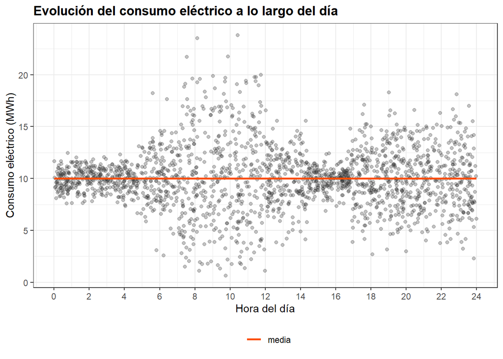

```r
p <- ggplot() +
  geom_point( data = datos, aes(x = hora, y = consumo), alpha = 0.3, color = "gray20") +
  geom_line( data = datos, aes(x = hora , y = 10, color = "media"), linetype = "solid", size = 1) +
  scale_color_manual(name = "", breaks = c("media"), values = c("media" = "#FC4E07")) +
  labs(title = "Evolución del consumo eléctrico a lo largo del día", x = "Hora del día", y = "Consumo eléctrico (MWh)") +
  theme_bw() + theme(legend.position = "bottom", plot.title = element_text(face = "bold"))
p <- p + scale_x_continuous(breaks = seq(0, 24, 2), labels = seq(0, 24, 2))
p
```

```r
library(quantreg)
```

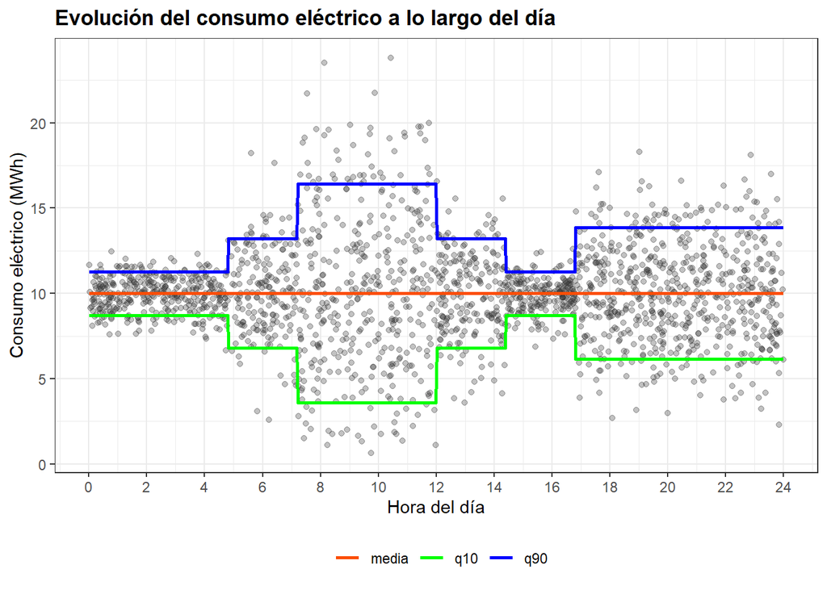

```r
p <- ggplot() +
  geom_point( data = datos, aes(x = hora, y = consumo), alpha = 0.3, color = "gray20") +
  geom_quantile(quantiles=c(0.1,0.9),color="firebrick") +
  geom_line( data = datos, aes(x = hora , y = cuantil_10, color = "q10"), linetype = "solid", size = 1) +
  geom_line( data = datos, aes(x = hora , y = cuantil_90, color = "q90"), linetype = "solid", size = 1) +
  geom_line( data = datos, aes(x = hora , y = 10.02138, color = "media"), linetype = "solid", size = 1) +
  scale_color_manual(name = "", breaks = c("media","q10","q90"), values = c("media" = "#FC4E07","q10"="green","q90"="blue")) +
  labs(title = "Evolución del consumo eléctrico a lo largo del día", x = "Hora del día", y = "Consumo eléctrico (MWh)") +
  theme_bw() + theme(legend.position = "bottom", plot.title = element_text(face = "bold"))
p <- p + scale_x_continuous(breaks = seq(0, 24, 2), labels = seq(0, 24, 2))
p
```

Observemos que un modelo que predice el promedio no permite responder a la pregunta de si es necesario producir en todas las horas la cantidad de energía consumida en promedio, ya que tanto para las 2 am de la mañana como para las 8 am, el consumo promedio predicho es de 10 MWh aproximadamente, sin embargo, la probabilidad de que se alcancen consumos de 15 MWh a las 2 am es prácticamente nula mientras que esto ocurra a las 8 am sí es factible.

### Regresión de cuantiles

Estimación del cuantil 0,9 usando regresión lineal.

```r
library(quantreg)

modelo_q09 <- rq(formula = consumo ~ hora, tau = 0.9, data = datos)
summary(modelo_q09)
```

```
##
## Call: rq(formula = consumo ~ hora, tau = 0.9, data = datos)
##
## tau: [1] 0.9
##
## Coefficients:
##             Value    Std. Error t value  Pr(>|t|)
## (Intercept) 12.42852  0.30559   40.67048  0.00000
## hora         0.07832  0.01940    4.03790  0.00006
```

```
## Smoothing formula not specified. Using: y ~ x
```

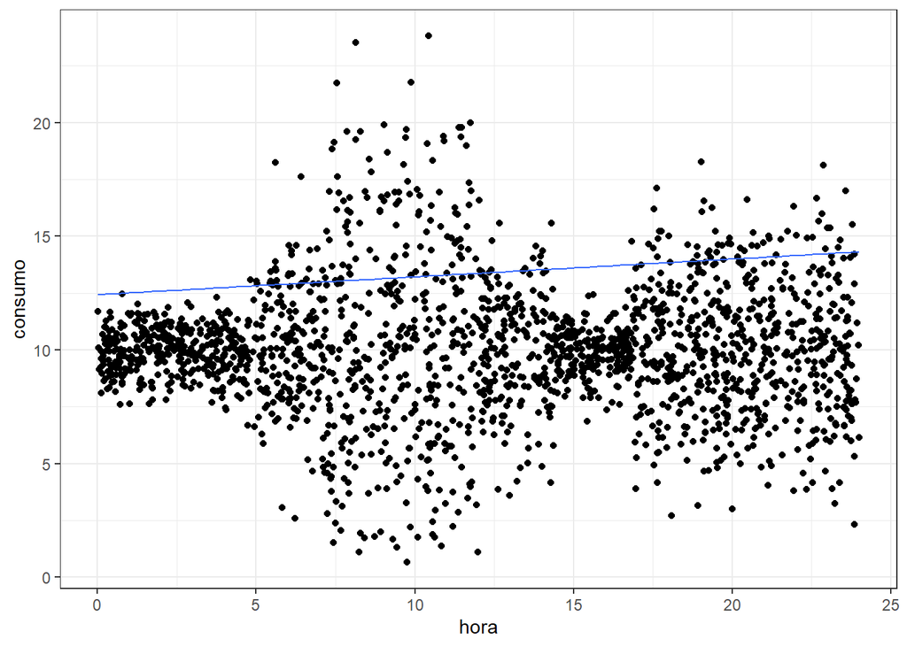

```r
ggplot(data = datos, aes(x = hora, y = consumo)) +
  geom_point() +
  geom_quantile(quantiles = 0.9) +
  theme_bw()
```

Estimación de deciles por regresión lineal.

```r
modelo_q <- rq(formula = consumo ~ hora, tau = c(0.1,0.2,0.3,0.4,0.5,0.6,0.7,0.8,0.9), data = datos)
summary(object = modelo_q, se = "boot")
```

```
##
## Call: rq(formula = consumo ~ hora, tau = c(0.1, 0.2, 0.3, 0.4, 0.5,
##     0.6, 0.7, 0.8, 0.9), data = datos)
##
## tau: [1] 0.1
##
## Coefficients:
##             Value    Std. Error t value  Pr(>|t|)
## (Intercept)  7.58265  0.27307   27.76864  0.00000
## hora        -0.06723  0.01746   -3.85149  0.00012
##
## Call: rq(formula = consumo ~ hora, tau = c(0.1, 0.2, 0.3, 0.4, 0.5,
##     0.6, 0.7, 0.8, 0.9), data = datos)
##
## tau: [1] 0.2
##
## Coefficients:
##             Value    Std. Error t value  Pr(>|t|)
## (Intercept)  8.67360  0.09980   86.91237  0.00000
## hora        -0.05591  0.00876   -6.38471  0.00000
##
## Call: rq(formula = consumo ~ hora, tau = c(0.1, 0.2, 0.3, 0.4, 0.5,
##     0.6, 0.7, 0.8, 0.9), data = datos)
##
## tau: [1] 0.3
##
## Coefficients:
##             Value    Std. Error t value  Pr(>|t|)
## (Intercept)  9.21985  0.11355   81.19355  0.00000
## hora        -0.03440  0.00896   -3.83832  0.00013
##
## Call: rq(formula = consumo ~ hora, tau = c(0.1, 0.2, 0.3, 0.4, 0.5,
##     0.6, 0.7, 0.8, 0.9), data = datos)
##
## tau: [1] 0.4
##
## Coefficients:
##             Value     Std. Error t value   Pr(>|t|)
## (Intercept)   9.64159   0.09092  106.04263   0.00000
## hora         -0.01732   0.00857   -2.02053   0.04346
```

[output cut: 35 more lines]

```
##
## Coefficients:
##             Value    Std. Error t value  Pr(>|t|)
## (Intercept) 11.11834  0.14774   75.25420  0.00000
## hora         0.06913  0.01348    5.12967  0.00000
##
## Call: rq(formula = consumo ~ hora, tau = c(0.1, 0.2, 0.3, 0.4, 0.5,
##     0.6, 0.7, 0.8, 0.9), data = datos)
##
## tau: [1] 0.9
##
## Coefficients:
##             Value    Std. Error t value  Pr(>|t|)
## (Intercept) 12.42852  0.26323   47.21581  0.00000
## hora         0.07832  0.01891    4.14231  0.00004
```

```
## Smoothing formula not specified. Using: y ~ x
```

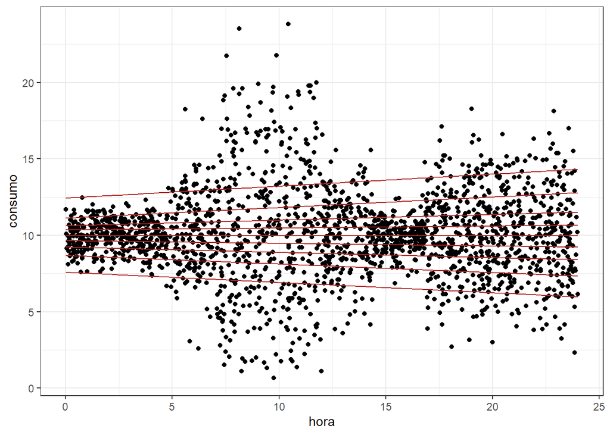

```r
ggplot(data = datos, aes(x = hora, y = consumo)) +
  geom_point() +
  geom_quantile(quantiles=c(0.1,0.2,0.3,0.4,0.5,0.6,0.7,0.8,0.9),color="firebrick") +
  theme_bw()
```

Observamos que una regresión lineal acá no es apropiada para estimar los deciles. Recurrimos a modeos GAMLSS.

### GAMLSS

En este caso sabemos cuál es la distribución de la variable respuesta porque fue simulada, pero sino podríamos buscar cuál es la distribución que mejor ajusta a la variable usando la función “fitDist”.

La función fitDist() ajusta toda las distribuciones paramétricas disponibles de una determinada familia, y las compara acorde al GAIC (generalized Akaike information criterion). La familia de distribuciones se especifica con el argumento type y puede ser: “realAll”, “realline”, “realplus”, “real0to1”, “counts” y “binom”.

• realAll: distribuciones de la familia realline + realplus.

• realline: distribuciones continuas en el dominio (−∞,∞): NO, GU, RG ,LO, NET, TF, TF2, PE,PE2, SN1, SN2, exGAUS, SHASH, SHASHo, SHASHo2, EGB2, JSU, JSUo, SEP1, SEP2, SEP3, SEP4, ST1, ST2, ST3, ST4, ST5, SST, GT.

• realplus: distribuciones continuas en el dominio (0,∞]: EXP, GA,IG,LOGNO, LOGNO2,WEI, WEI2, WEI3, IGAMMA,PARETO2, PARETO2o, GP, BCCG, BCCGo, exGAUS, GG, GIG, LNO,BCTo, BCT, BCPEo, BCPE, GB2.

• real0to1: distribuciones continuas en el dominio [0,1]: BE, BEo, BEINF0, BEINF1, BEOI, BEZI, BEINF, GB1.

• counts: distribuciones para cuentas: PO, GEOM, GEOMo,LG, YULE, ZIPF, WARING, GPO, DPO, BNB, NBF,NBI, NBII, PIG, ZIP,ZIP2, ZAP, ZALG, DEL, ZAZIPF, SI, SICHEL,ZANBI, ZAPIG, ZINBI, ZIPIG, ZINBF, ZABNB, ZASICHEL, ZINBF, ZIBNB, ZISICHEL.

• binom: distribuciones para datos binomiales: BI, BB, DB, ZIBI, ZIBB, ZABI, ZABB.

```r
library(gamlss)
distribuciones <- fitDist( y = datos$consumo, k = log(length(datos$consumo)), type = "realAll", trace = FALSE, try.gamlss = TRUE, parallel = "multicore", ncpus = 3L )
```

```
##
##   Lapack routine dgesv: system is exactly singular: U[3,3] = 0
##
```

```r
distribuciones$fits %>% enframe(name = "distribucion", value = "GAIC") %>% arrange(GAIC)
```

| distribucion | GAIC |
| --- | --- |
| BCPEo | 9713.672 |
| BCPE | 9713.672 |
| PE | 9721.935 |
| PE2 | 9721.935 |
| SEP4 | 9725.212 |
| SHASH | 9725.379 |
| SHASHo | 9727.126 |
| SHASHo2 | 9727.126 |
| SEP3 | 9728.050 |
| SEP1 | 9728.410 |

[output cut: 41 more lines]

```r
summary(distribuciones)
```

```
## Family:  c("BCPEo", "Box-Cox Power Exponential-orig.")
##
## Call:  gamlssML(formula = y, family = DIST[i], parallel = "multicore",
##     ncpus = 3L)
##
## Fitting method: "nlminb"
##
##
## Coefficient(s):
##              Estimate  Std. Error   t value   Pr(>|t|)
## eta.mu     2.29921999  0.00470689 488.48009 < 2.22e-16 ***
## eta.sigma -1.20367737  0.02774279 -43.38703 < 2.22e-16 ***
## eta.nu     0.90889687  0.11650770   7.80117 6.2172e-15 ***
## eta.tau    0.04484255  0.04777392   0.93864    0.34792
## ---
## Signif. codes:  0 '***' 0.001 '**' 0.01 '*' 0.05 '.' 0.1 ' ' 1
##
##  Degrees of Freedom for the fit: 4 Residual Deg. of Freedom   1986
## Global Deviance:     9683.29
##             AIC:     9691.29
##             SBC:     9713.67
```

Usamos GAMLSS basado en la familia Normal que es la distribución que tiene el consumo.

```r
modelo1 <- gamlss( formula = consumo~ pb(hora), sigma.formula = ~ pb(hora), family = NO, data = datos, control = gamlss.control(trace = FALSE) )
summary(modelo1)
```

```
## Family:  c("NO", "Normal")
##
## Call:  gamlss(formula = consumo ~ pb(hora), sigma.formula = ~pb(hora),
##     family = NO, data = datos, control = gamlss.control(trace = FALSE))
##
## Fitting method: RS()
##
## ------------------------------------------------------------------
## Mu link function:  identity
## Mu Coefficients:
##               Estimate Std. Error t value Pr(>|t|)
## (Intercept)  9.9549493  0.0591163 168.396   <2e-16 ***
## pb(hora)    -0.0008836  0.0053652  -0.165    0.869
## ---
## Signif. codes:  0 '***' 0.001 '**' 0.01 '*' 0.05 '.' 0.1 ' ' 1
##
## ------------------------------------------------------------------
## Sigma link function:  log
## Sigma Coefficients:
##             Estimate Std. Error t value Pr(>|t|)
## (Intercept) 0.481390   0.032502   14.81   <2e-16 ***
## pb(hora)    0.028841   0.002298   12.55   <2e-16 ***
## ---
## Signif. codes:  0 '***' 0.001 '**' 0.01 '*' 0.05 '.' 0.1 ' ' 1
##
## ------------------------------------------------------------------
## NOTE: Additive smoothing terms exist in the formulas:
##  i) Std. Error for smoothers are for the linear effect only.
## ii) Std. Error for the linear terms maybe are not accurate.
## ------------------------------------------------------------------
## No. of observations in the fit:  1990
## Degrees of Freedom for the fit:  18.02599
##       Residual Deg. of Freedom:  1971.974
##                       at cycle:  4
##
## Global Deviance:     8980.308
##             AIC:     9016.36
##             SBC:     9117.232
```

Si probamos con la familia de distribuciones sugerida por la función “fitDist” encontramos que hay que tener en cuenta más parámetros adempas de mu y sigma. Se agregan nu y tau. Como resulta más complejo nos quedaremos con el modelo 1.

```r
modelo2 <- gamlss( formula = consumo~ pb(hora), sigma.formula = ~ pb(hora), family = BCPEo, data = datos, control = gamlss.control(trace = FALSE) )
summary(modelo2)
```

```
## Family:  c("BCPEo", "Box-Cox Power Exponential-orig.")
##
## Call:  gamlss(formula = consumo ~ pb(hora), sigma.formula = ~pb(hora),
##     family = BCPEo, data = datos, control = gamlss.control(trace = FALSE))
##
## Fitting method: RS()
##
## ------------------------------------------------------------------
## Mu link function:  log
## Mu Coefficients:
##               Estimate Std. Error t value Pr(>|t|)
## (Intercept)  2.3066296  0.0059705 386.335   <2e-16 ***
## pb(hora)    -0.0007837  0.0005473  -1.432    0.152
## ---
## Signif. codes:  0 '***' 0.001 '**' 0.01 '*' 0.05 '.' 0.1 ' ' 1
##
## ------------------------------------------------------------------
## Sigma link function:  log
## Sigma Coefficients:
##              Estimate Std. Error t value Pr(>|t|)
## (Intercept) -1.801543   0.033921  -53.11   <2e-16 ***
## pb(hora)     0.028613   0.002396   11.94   <2e-16 ***
## ---
## Signif. codes:  0 '***' 0.001 '**' 0.01 '*' 0.05 '.' 0.1 ' ' 1
##
## ------------------------------------------------------------------
## Nu link function:  identity
## Nu Coefficients:
##             Estimate Std. Error t value Pr(>|t|)
## (Intercept)  0.94134    0.07587   12.41   <2e-16 ***
## ---
## Signif. codes:  0 '***' 0.001 '**' 0.01 '*' 0.05 '.' 0.1 ' ' 1
##
## ------------------------------------------------------------------
## Tau link function:  log
## Tau Coefficients:
##             Estimate Std. Error t value Pr(>|t|)
## (Intercept)  0.68625    0.05232   13.12   <2e-16 ***
## ---
## Signif. codes:  0 '***' 0.001 '**' 0.01 '*' 0.05 '.' 0.1 ' ' 1
##
## ------------------------------------------------------------------
## NOTE: Additive smoothing terms exist in the formulas:
##  i) Std. Error for smoothers are for the linear effect only.
## ii) Std. Error for the linear terms maybe are not accurate.
## ------------------------------------------------------------------
## No. of observations in the fit:  1990
## Degrees of Freedom for the fit:  20.30175
##       Residual Deg. of Freedom:  1969.698
##                       at cycle:  11
##
## Global Deviance:     8964.491
##             AIC:     9005.094
##             SBC:     9118.701
```

Predicción de cuantiles usando el modelo 1 de GAMLSS.

```r
# Se predice todo el rango de hora para representar los cuantiles
grid_predictor <- seq(0, 24, length.out = 2500)
predicciones <- predictAll( modelo1, newdata = data.frame(hora = grid_predictor), type = "response" )
```

```
## new prediction
## New way of prediction in pb()  (starting from GAMLSS version 5.0-3)
## new prediction
## New way of prediction in pb()  (starting from GAMLSS version 5.0-3)
```

```r
predicciones <- as.data.frame(predicciones)
predicciones <- bind_cols(data.frame(hora = grid_predictor), predicciones)
predicciones %>% head()
```

|  | hora | mu | sigma |
| --- | --- | --- | --- |
| 1 | 0.000000000 | 9.954907 | 0.9048709 |
| 2 | 0.009603842 | 9.954899 | 0.9065713 |
| 3 | 0.019207683 | 9.954891 | 0.9082748 |
| 4 | 0.028811525 | 9.954882 | 0.9099789 |
| 5 | 0.038415366 | 9.954874 | 0.9116814 |
| 6 | 0.048019208 | 9.954865 | 0.9133818 |

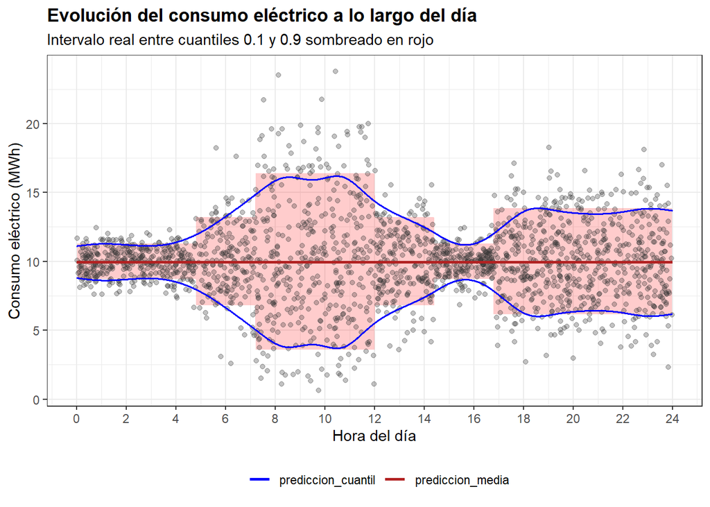

```r
# Se calculan los cuantiles teóricos para establecer el intervalo central que acumula
# un 90% de probabilidad empleando los parámetros predichos.
predicciones1 <- predicciones %>% mutate(
  cuantil_10_pred = purrr::pmap_dbl(
  .l = list(mu = mu, sigma = sigma),
  .f = function(mu, sigma) {qNO(p = 0.1, mu, sigma)} ),
  cuantil_90_pred = purrr::pmap_dbl(
    .l = list(mu = mu, sigma = sigma),
    .f = function(mu, sigma) {qNO(p = 0.9, mu, sigma)} ) )

p <- ggplot() + geom_ribbon( data = datos, aes(x = hora, ymin = cuantil_10, ymax = cuantil_90), fill = "red", alpha = 0.2) +
  geom_point( data = datos, aes(x = hora, y = consumo), alpha = 0.3, color = "gray20") +
  geom_line( data = predicciones1, aes(x = hora, y = cuantil_10_pred, color = "prediccion_cuantil"), size = 0.7) +
  geom_line( data = predicciones1, aes(x = hora, y = cuantil_90_pred, color = "prediccion_cuantil"), size = 0.7) +
  geom_line( data = predicciones1, aes(x = hora, y = mu, color = "prediccion_media"), size = 1) +
  scale_color_manual(name = "", breaks = c("prediccion_cuantil", "prediccion_media"),
                   values = c("prediccion_cuantil" = "blue", "prediccion_media" = "firebrick")) +
  labs(title = "Evolución del consumo eléctrico a lo largo del día",
       subtitle = "Intervalo real entre cuantiles 0.1 y 0.9 sombreado en rojo",
       x = "Hora del día", y = "Consumo eléctrico (MWh)") + theme_bw() +
  theme(legend.position = "bottom", plot.title = element_text(face = "bold"))
p <- p + scale_x_continuous(breaks = seq(0, 24, 2), labels = seq(0, 24, 2))
p
```

Si, por ejemplo, se desea conocer la probabilidad de que a las 8 hs el consumo supere los 15 MWh, primero se predicen los parámetros de la distribución para la hora 8 y después se calcula la probabilidad de consumo≥15 con su función de distribución.

```r
pred<- predictAll( modelo1, newdata = data.frame(hora = 8), type = "response" )
```

```
## new prediction
## New way of prediction in pb()  (starting from GAMLSS version 5.0-3)
## new prediction
## New way of prediction in pb()  (starting from GAMLSS version 5.0-3)
```

```r
pred
```

```
## $mu
## [1] 9.947882
##
## $sigma
## [1] 4.607569
##
## attr(,"family")
## [1] "NO"     "Normal"
```

```r
# Se calcula la probabilidad
prob_consumo <- pNO( q = 15, mu = pred$mu, sigma = pred$sigma, lower.tail = FALSE )
prob_consumo
```

```
## [1] 0.1364339
```

De acuerdo al modelo, la probabilidad de que a las 8 hs el consumo sea igual o superior a 15 MWh es del 13,6%.

# Regresión logística

## Ejemplo

Se observaron dos grupos de salmones: de Alaska y de Canadá. Se determinó el número de una sustancia química producida por su permanencia en agua dulce o en el mar. Se quiere establecer un modelo que prediga de qué origen es el salmón conociendo ambas cantidades de sustancias. (Se sabe que los salmones migran de océanos a ríos y al revés).

### Primer análisis

```r
library(readxl)
library(ggplot2)
library(ggpubr)

salmon <- read_excel("salmon.xlsx")
head(salmon)
```

| origen | aguadulce | mar |
| --- | --- | --- |
| Alaska | 108 | 368 |
| Alaska | 131 | 355 |
| Alaska | 105 | 469 |
| Alaska | 86 | 506 |
| Alaska | 99 | 402 |
| Alaska | 87 | 423 |

```r
dim(salmon)
```

```
## [1] 100   3
```

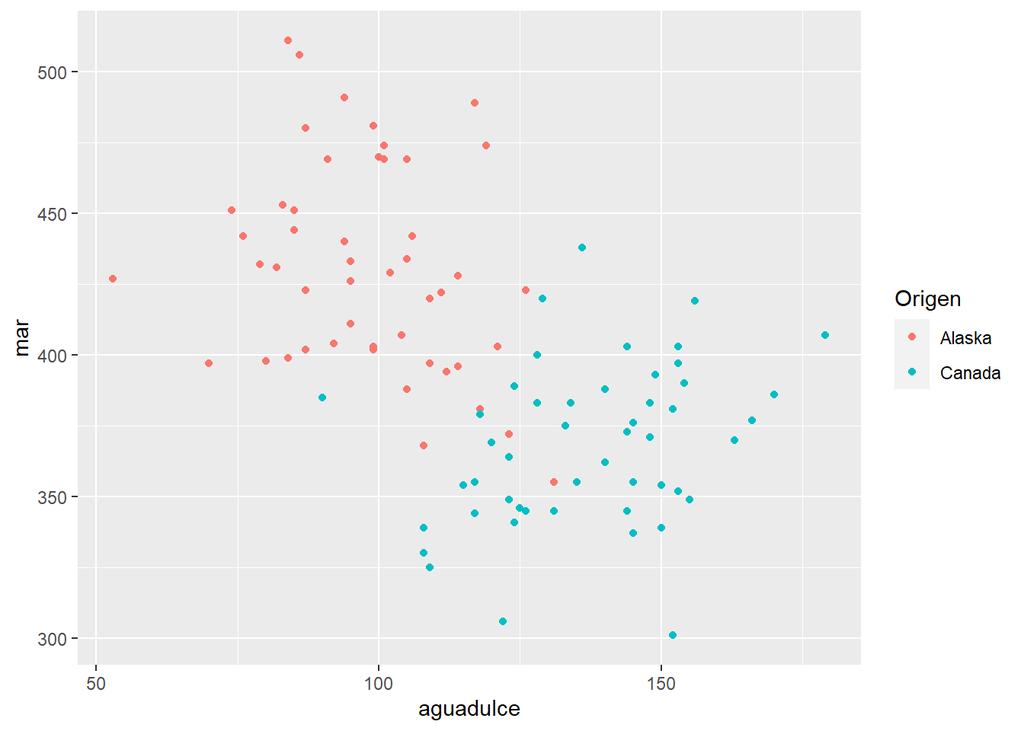

```r
Origen=factor(salmon$origen)
p1=ggplot(aes(x=aguadulce,y=mar,fill=Origen,color=Origen),data=salmon)+
  geom_point(aes(x=aguadulce,y=mar))
p1
```

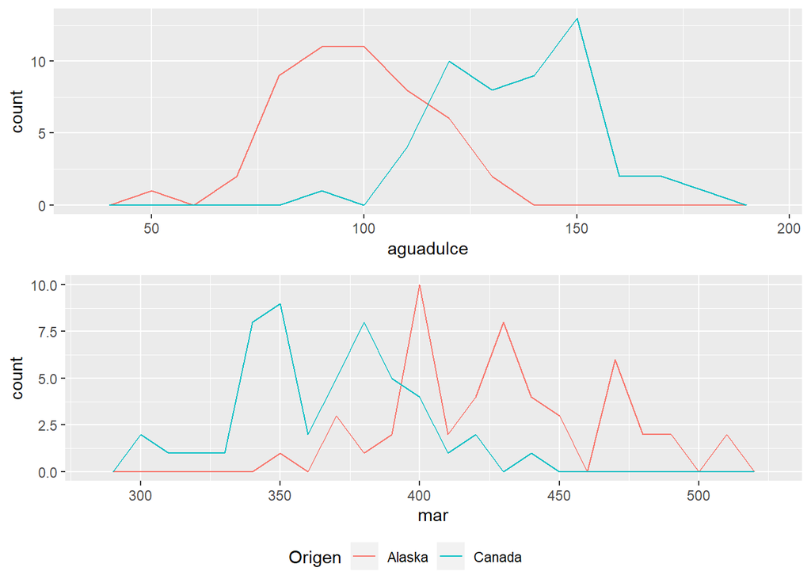

```r
pdul <- ggplot(salmon, aes(aguadulce, colour = Origen)) +
  geom_freqpoly(binwidth = 10)

pmar <-ggplot(salmon, aes(mar, colour = Origen)) +
  geom_freqpoly(binwidth = 10)
ggarrange(pdul, pmar, nrow = 2, common.legend = TRUE, legend = "bottom")
```

```r
Alaska0_Canada1<-ifelse(Origen=="Alaska",0,1)
table(Alaska0_Canada1)
```

```
## Alaska0_Canada1
##  0  1
## 50 50
```

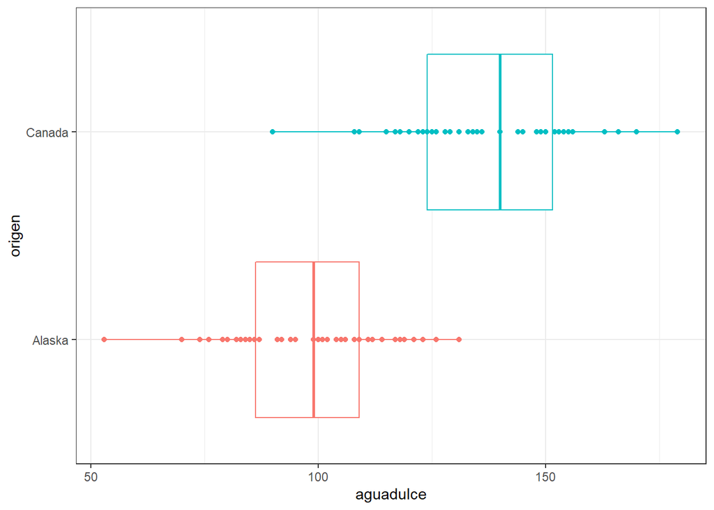

```r
p2<-ggplot(data=salmon,aes(x = aguadulce, y= origen)) +
  geom_boxplot(aes(color = origen)) + geom_point(aes(color = origen)) +
  theme_bw() + theme(legend.position = "null")
p2
```

### Modelo logístico

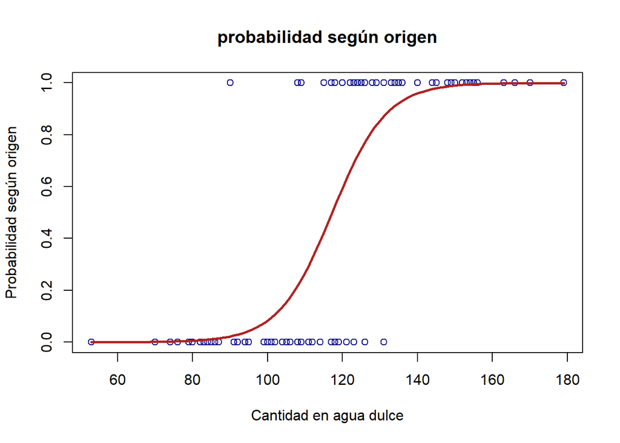

```r
modelo_logistico <- glm(Alaska0_Canada1 ~ aguadulce,data=salmon, family = "binomial")

plot(x = salmon$aguadulce, y = Alaska0_Canada1, col = "darkblue", main = "probabilidad según origen", xlab = "Cantidad en agua dulce", ylab = "Probabilidad según origen")
curve(predict(modelo_logistico, data.frame(aguadulce=x), type = "response"), add = TRUE, col = "firebrick", lwd = 2.5)
```

```r
summary(modelo_logistico)
```

```
##
## Call:
## glm(formula = Alaska0_Canada1 ~ aguadulce, family = "binomial",
##     data = salmon)
##
## Deviance Residuals:
##     Min       1Q   Median       3Q      Max
## -2.0278  -0.3898   0.0015   0.2865   2.7625
##
## Coefficients:
##              Estimate Std. Error z value Pr(>|z|)
## (Intercept) -16.33244    3.37525  -4.839 1.31e-06 ***
## aguadulce     0.13932    0.02875   4.846 1.26e-06 ***
## ---
## Signif. codes:  0 '***' 0.001 '**' 0.01 '*' 0.05 '.' 0.1 ' ' 1
##
## (Dispersion parameter for binomial family taken to be 1)
##
##     Null deviance: 138.629  on 99  degrees of freedom
## Residual deviance:  58.029  on 98  degrees of freedom
## AIC: 62.029
##
## Number of Fisher Scoring iterations: 6
```

```r
modelo_logistico$coefficients
```

```
## (Intercept)   aguadulce
## -16.3324353   0.1393236
```

```r
confint(object = modelo_logistico, level = 0.95)
```

```
##                    2.5 %      97.5 %
## (Intercept) -24.20323367 -10.7359637
## aguadulce     0.09169013   0.2063183
```

```r
#modelo_logistico$residuals
#modelo_logistico$aic
#modelo_logistico$fitted.values#coincide con lo de abajo

#predict(modelo_logistico, data.frame(aguadulce=salmon$aguadulce), type = "response")
```

### Predicciones sobre nuevas observaciones

Se crea un vector con nuevos valores en el rango de observaciones.

```r
 nuevos_puntos <- seq(from = min(salmon$aguadulce), to = max(salmon$aguadulce), by = 0.5)
```

Calculamos las predicciones de los nuevos puntos según el modelo. Si se indica se.fit = TRUE se devuelve el error estándar de cada predicción junto con el valor de la predicción (fit).

```r
predicciones <- predict(modelo_logistico, data.frame(aguadulce = nuevos_puntos), se.fit = TRUE)
```

Mediante la función logit se transforman los log_ODDs en probabilidades.

```r
predicciones_logit <- exp(predicciones$fit)/(1 + exp(predicciones$fit))
```

Se calcula el límite inferior y superior del IC del 95%. Una vez calculados los logODDs del intervalo se transforman en probabilidades con la función logit.

```r
limite_inferior <- predicciones$fit - 1.96 * predicciones$se.fit
limite_inferior_logit <- exp(limite_inferior)/(1 + exp(limite_inferior))
limite_superior <- predicciones$fit + 1.96 * predicciones$se.fit
limite_superior_logit <- exp(limite_superior)/(1 + exp(limite_superior))
```

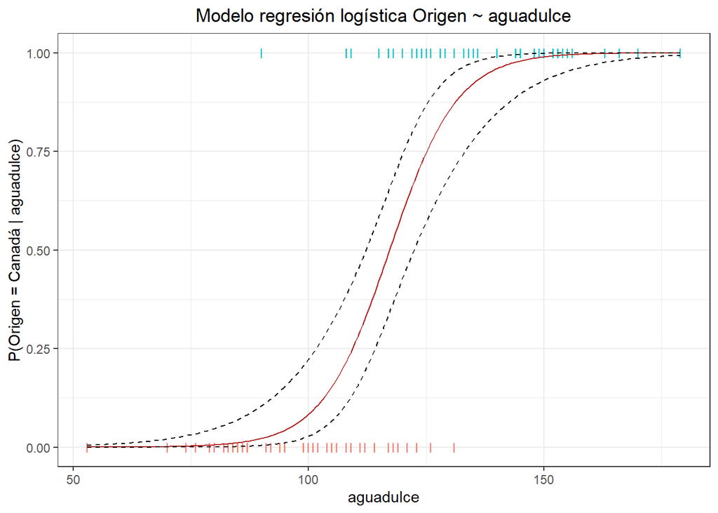

```r
datos_curva <- data.frame(aguadulce = nuevos_puntos, probabilidad_aguadulce = predicciones_logit, limite_inferior_logit = limite_inferior_logit, limite_superior_logit = limite_superior_logit)
ggplot(salmon, aes(x = aguadulce, y = Alaska0_Canada1)) +
  geom_point(aes(color = as.factor(Origen)),shape = "I", size = 3) +
  geom_line(data = datos_curva, aes(y = probabilidad_aguadulce), color = "firebrick") +
  geom_line(data = datos_curva, aes(y = limite_inferior_logit), linetype = "dashed") +
  geom_line(data = datos_curva, aes(y = limite_superior_logit), linetype = "dashed") +
  theme_bw() +
  labs(title = "Modelo regresión logística Origen ~ aguadulce", y = "P(Origen = Canadá | aguadulce)", y = "Origen") +
  theme(legend.position = "null") + theme(plot.title = element_text(hjust = 0.5))
```

La diferencia de residuos de un objeto glm se almacena en la ‘deviance’ del modelo, así como la ‘deviance’ del modelo nulo.

```r
dif_residuos <- modelo_logistico$null.deviance - modelo_logistico$deviance

# Grados libertad
df <- modelo_logistico$df.null - modelo_logistico$df.residual
# p-value
p_value <- pchisq(q = dif_residuos, df = df, lower.tail = FALSE)

paste("Diferencia de residuos:", round(dif_residuos, 4))
```

```
## [1] "Diferencia de residuos: 80.6008"
```

```r
paste("Grados de libertad:", df)#"Grados de libertad: 1"
```

```
## [1] "Grados de libertad: 1"
```

```r
paste("p-value:", p_value)#"p-value: 2.76249182543243e-19"
```

```
## [1] "p-value: 2.76249182543244e-19"
```

El mismo cálculo anterior se puede obtener directamente con: anova(modelo, test =‘Chisq’).

```r
anova(modelo_logistico, test ='Chisq')
```

|  | Df | Deviance | Resid. Df | Resid. Dev | Pr(>Chi) |
| --- | --- | --- | --- | --- | --- |
| NULL | NA | NA | 99 | 138.62944 | NA |
| aguadulce | 1 | 80.60079 | 98 | 58.02865 | 2.762492e-19 |

### Nuevo modelo

Incorporamos la segunda covariable.

```r
modelo_logistico2 <- glm(Alaska0_Canada1 ~ aguadulce+mar,data=salmon, family = "binomial")
summary(modelo_logistico2)
```

```
##
## Call:
## glm(formula = Alaska0_Canada1 ~ aguadulce + mar, family = "binomial",
##     data = salmon)
##
## Deviance Residuals:
##      Min        1Q    Median        3Q       Max
## -2.54720  -0.12571   0.00611   0.22736   2.62765
##
## Coefficients:
##             Estimate Std. Error z value Pr(>|z|)
## (Intercept)  3.92484    6.31518   0.621 0.534275
## aguadulce    0.12605    0.03586   3.515 0.000439 ***
## mar         -0.04854    0.01452  -3.342 0.000831 ***
## ---
## Signif. codes:  0 '***' 0.001 '**' 0.01 '*' 0.05 '.' 0.1 ' ' 1
##
## (Dispersion parameter for binomial family taken to be 1)
##
##     Null deviance: 138.629  on 99  degrees of freedom
## Residual deviance:  38.788  on 97  degrees of freedom
## AIC: 44.788
##
## Number of Fisher Scoring iterations: 7
```

### Prueba de verosimilitud

```r
#install.packages("lmtest", repos = "http://cran.us.r-project.org", dependencies = TRUE)
library(lmtest)
#Prueba de verosimilitud
lrtest<-lrtest(modelo_logistico, modelo_logistico2)
lrtest
```

|  | #Df | LogLik | Df | Chisq | Pr(>Chisq) |
| --- | --- | --- | --- | --- | --- |
| 1 | 2 | -29.01432 | NA | NA | NA |
| 2 | 3 | -19.39419 | 1 | 19.24026 | 1.15257e-05 |

### Test de Hosmer y Lemeshow de bondad de ajuste

En este caso, no queremos rechazar el test porque la hipótesis nula H0 es que el modelo ajusta bien a los datos.

```r
#install.packages("ResourceSelection", repos = "http://cran.us.r-project.org", dependencies = TRUE)
library(ResourceSelection)
```

```
## ResourceSelection 0.3-5   2019-07-22
```

```r
hoslem.test(Alaska0_Canada1, fitted(modelo_logistico2))
```

```
##
##  Hosmer and Lemeshow goodness of fit (GOF) test
##
## data:  Alaska0_Canada1, fitted(modelo_logistico2)
## X-squared = 4.9027, df = 8, p-value = 0.7679
```

```r
hoslem.test(Alaska0_Canada1, fitted(modelo_logistico))
```

```
##
##  Hosmer and Lemeshow goodness of fit (GOF) test
##
## data:  Alaska0_Canada1, fitted(modelo_logistico)
## X-squared = 5.0731, df = 8, p-value = 0.7497
```

### Curva ROC y métricas de interés

Matriz de confusión

```r
#install.packages("vcd", repos = "http://cran.us.r-project.org", dependencies = TRUE)
library(vcd)
predicciones <- ifelse(test = modelo_logistico$fitted.values > 0.5, yes = 1, no = 0)
matriz_confusion <- table(Alaska0_Canada1, predicciones, dnn = c("observaciones", "predicciones"))
matriz_confusion
```

```
##              predicciones
## observaciones  0  1
##             0 43  7
##             1  7 43
```

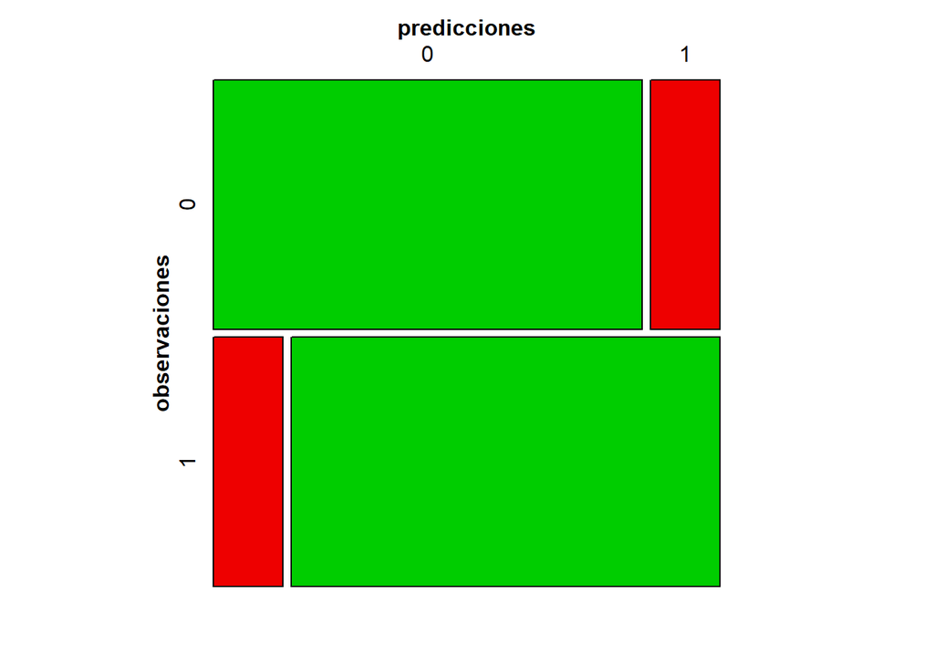

```r
mosaic(matriz_confusion, shade = T, colorize = T, gp = gpar(fill = matrix(c("green3", "red2", "red2", "green3"), 2, 2)))
```

Separación en muestra de entrenamiento y test para obtener métricas de test.

```r
library(pROC)
set.seed(2019)
entrenamiento<-sample(1:100,70)

validacion<-c(1:100)[-entrenamiento]

salmon_train<-salmon[entrenamiento,]
salmon_test<-salmon[validacion,]
Alaska0_Canada1_train<-Alaska0_Canada1[entrenamiento]
table(Alaska0_Canada1_train)
```

```
## Alaska0_Canada1_train
##  0  1
## 37 33
```

```r
Alaska0_Canada1_test<-Alaska0_Canada1[validacion]
table(Alaska0_Canada1_test)
```

```
## Alaska0_Canada1_test
##  0  1
## 13 17
```

```r
salmon_new<-data.frame(salmon_test)
salmon_new$origen<-Alaska0_Canada1_test

# Se obtienen las probabilidades predichas para cada clase
predicciones <- predict(object = modelo_logistico2, newdata = salmon_new, type = "response")
```

Curva ROC sobre datos de test.

```r
curva_roc <- roc(response = salmon_new$origen, predictor = predicciones)
curva_roc
```

```
##
## Call:
## roc.default(response = salmon_new$origen, predictor = predicciones)
##
## Data: predicciones in 13 controls (salmon_new$origen 0) < 17 cases (salmon_new$origen 1).
## Area under the curve: 0.991
```

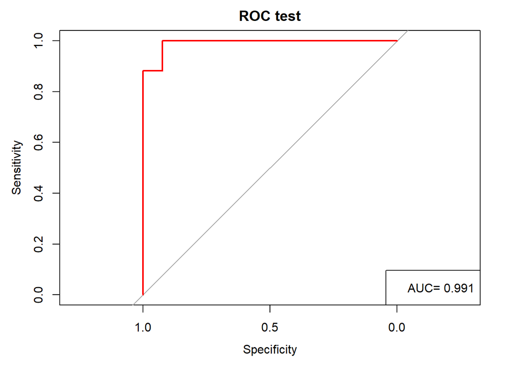

```r
# Gráfico de la curva
#plot(curva_roc)
plot(curva_roc,col="red",lwd=2,main="ROC test")
legend("bottomright",legend=paste("AUC=",round(auc(curva_roc),4)))
```

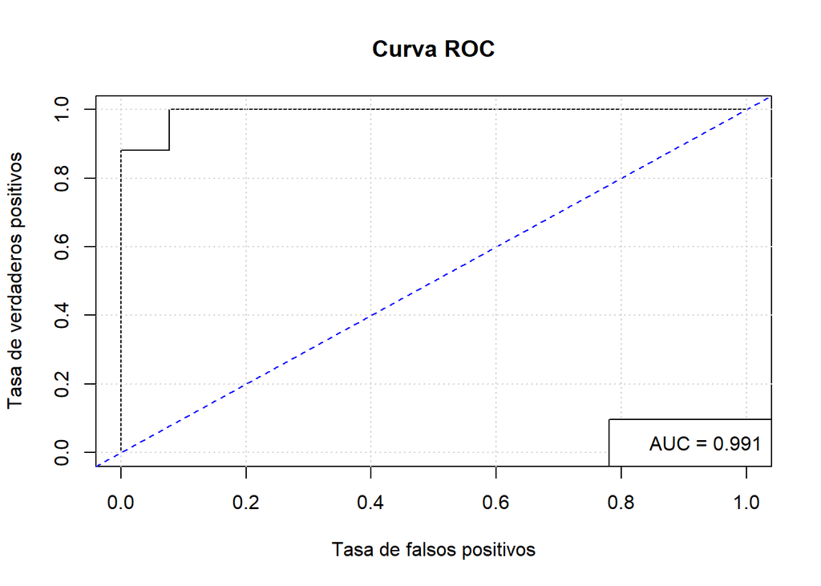

```r
# otra forma
#install.packages("ROCR", repos = "http://cran.us.r-project.org", dependencies = TRUE)
library(ROCR)

real <- salmon_new$origen

predic <-prediction(predicciones,real)
perf <-  performance(predic, "tpr","fpr")

plot(perf,
     main = "Curva ROC",
     xlab="Tasa de falsos positivos",
     ylab="Tasa de verdaderos positivos")
abline(a=0,b=1,col="blue",lty=2)
grid()
auc <- as.numeric(performance(predic,"auc")@y.values)
legend("bottomright",legend=paste(" AUC =",round(auc,4)))
```

Curva Recall vs Precision.

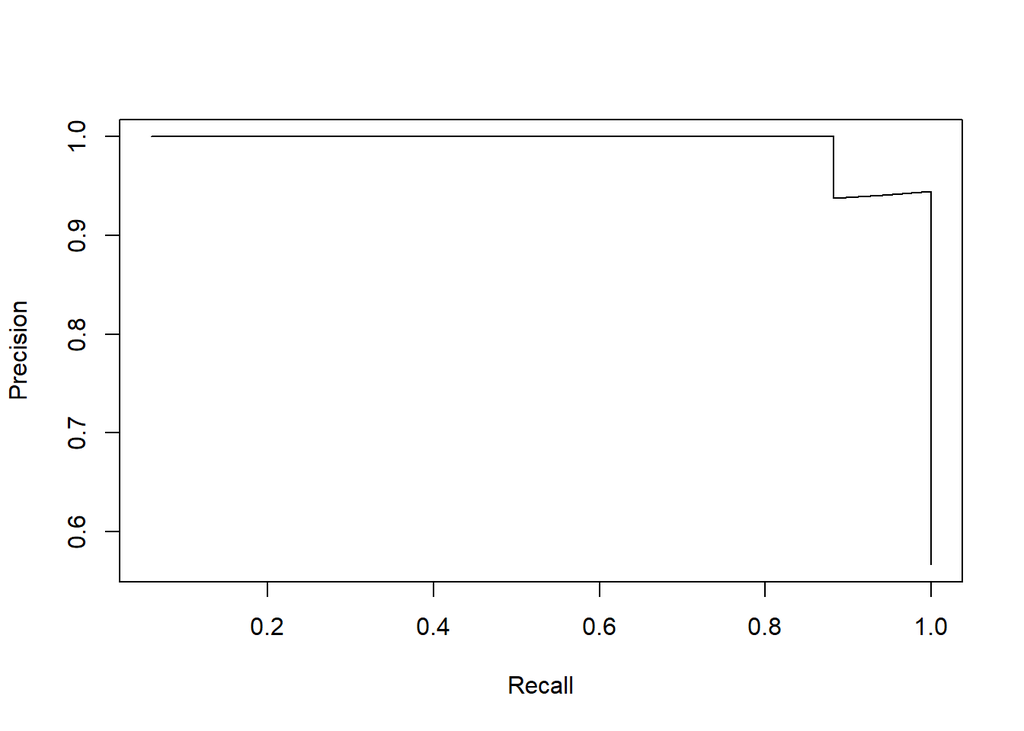

```r
RP.perf <- performance(predic, "prec", "rec");

plot (RP.perf);
```

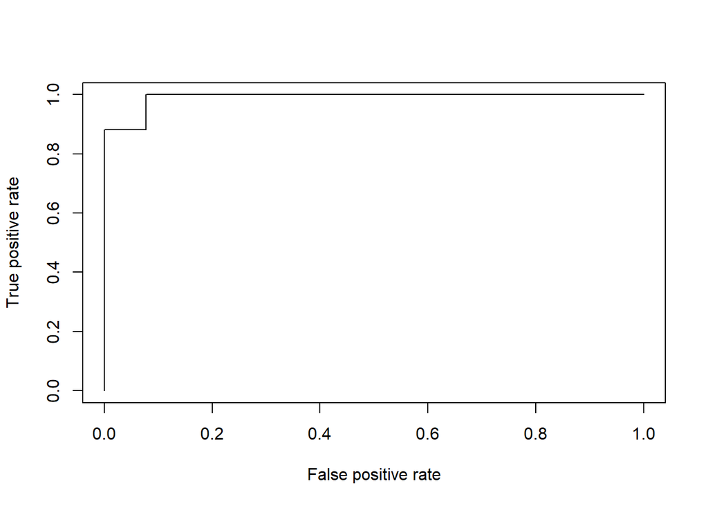

```r
# curva ROC
ROC.perf <- performance(predic, "tpr", "fpr");
plot (ROC.perf);
```

```r
# Área bajo la curva ROC
auc.tmp <- performance(predic,"auc");
auc <- as.numeric(auc.tmp@y.values)
auc
```

```
## [1] 0.9909502
```

Métricas de interés.

```r
actual_values<-Alaska0_Canada1_test
predict_value<-predicciones
table(ACTUAL=actual_values,PREDICTED=predict_value>0.5) # asumimos umbral de 0.5
```

```
##       PREDICTED
## ACTUAL FALSE TRUE
##      0    12    1
##      1     2   15
```

Recordemos que:

Precision : TP / (TP+FP)

Recall : TP / (TP+FN)

F1 Score : (2 * Precision * Recall) / (Precision+Recall)

```r
pred<-predict_value>0.5
TP<-length(actual_values[(actual_values==1)&(pred==1)])#15
TN<-length(actual_values[(actual_values==0)&(pred==0)])#12
FP<-length(actual_values[(actual_values==0)&(pred==1)])#1
FN<-length(actual_values[(actual_values==1)&(pred==0)])#2

precision<-TP/(TP+FP)
precision
```

```
## [1] 0.9375
```

```r
recall<-TP/(TP+FN)
recall
```

```
## [1] 0.8823529
```

```r
f1_score<-(2*precision*recall)/(precision+recall)
f1_score
```

```
## [1] 0.9090909
```

```r
pred_test_RegLog_0_1<-ifelse(predict_value>0.5,1,0)#idem pred
error_RegLog<- mean(Alaska0_Canada1_test!= pred_test_RegLog_0_1) * 100
```